# Closing the Loop

by [Amanda Oliveira](https://www.linkedin.com/in/amanda-guedes-de-oliveira-0776366a/)

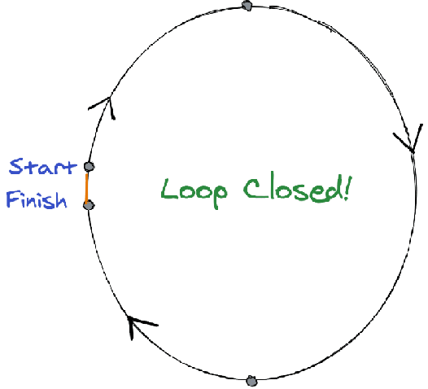

#### **Goals for this project**

Many scholars believe that learning analytics will not demonstrate real utility until it can “Close the Loop”, use data to automate decision making. A common example of this system are email generators that send emails to students in response to an activity (or lack of activity). Several universities have had some success with this strategy such as George Washington University. There are an infinite number of these loop closing activities that could be implemented and there is a lot of work to be done understanding when they are most useful.

In this project I will be working towards building a system that autogenerates a report and emails it to myself. I will download data from Twitter using a Twitter developer account. I will also discuss the consequences of automatically intervening in student activity.

#### **Resources**

###### **Package Documentation**

[RMarkdown Cheat Sheet](https://www.rstudio.com/wp-content/uploads/2016/03/rmarkdown-cheatsheet-2.0.pdf)

[cronR Documentation](https://rdrr.io/cran/cronR/f/README.md)

[sendmailR Documentation](https://cran.r-project.org/web/packages/sendmailR/index.html)

###### **Readings**

[Whitehill, J., Williams, J. J., Lopez, G., Coleman, C. A., & Reich, J. (2015). Beyond prediction: First steps toward automatic intervention in MOOC student stopout.](https://papers.ssrn.com/sol3/papers.cfm?abstract_id=2611750)

[Liu, R., & Koedinger, K. R. (2017). Closing the Loop: Automated Data-Driven Cognitive Model Discoveries Lead to Improved Instruction and Learning Gains. Journal of Educational Data Mining, 9(1), 25-41.](https://eric.ed.gov/?id=EJ1155896)

[Lawson, C., Beer, C., Rossi, D., Moore, T., & Fleming, J. (2016). Identification of “At Risk” Students Using Learning Analytics: The Ethical Dilemmas of Intervention Strategies in a Higher Education Institution. Educational Technology Research and Development, 64(5), 957–968.](https://doi.org/10.1007/s11423-016-9459-0)

###### **Videos**

[MuleSoft Videos. (2015). What is an API?](https://www.youtube.com/watch?v=s7wmiS2mSXY)

[Peng, R. (2015). R Markdown with RStudio](https://www.youtube.com/watch?v=DNS7i2m4sB0)

[Jalayer Academy. (2016).Twitter Mining with R](https://www.youtube.com/watch?v=lT4Kosc_ers)

###### **Podcast**

[Victoria, Oren, Xixuan & Meijuan discuss the complexities of closing the loop on ed tech products and review the algebra game DragonBox (dragonbox.com)](http://hudk4051.bandcamp.com/track/closing-the-loop)